# Investaging a dataset

**In this project ,I investigated the effection of Sex,Age and Fare on survival.Emphasis on serveral questions what puzzled me.**

> - What the characters distinguish the survivors and victims ?
> - Does the Sex impact the Survived or not?
> - What the Fare effects on Survival ?

```python
import csv
import pandas as pd
import numpy as np
import matplotlib.pyplot as plt
import seaborn as sns
from IPython.display import display
%matplotlib inline
```

```python
# parse the data, acquire the unique number

titanic_data = pd.read_csv('titanic-data.csv')
total_number = titanic_data['PassengerId'].unique()
print'The number of total titanic crew passenger : ',
print(len(total_number))
print'Compare unique PassengerId number with  length of Titanic_data:',
print(len(total_number)==len(titanic_data))
```

```
The number of total titanic crew passenger :  891
Compare unique PassengerId number with  length of Titanic_data: True
```

> The length of titanic_data equal the **unique number** of PassengerId , so the passengerId doesn't have same values

```python
titanic_data.describe()
```

|  | PassengerId | Survived | Pclass | Age | SibSp | Parch | Fare |
| --- | --- | --- | --- | --- | --- | --- | --- |
| count | 891.000000 | 891.000000 | 891.000000 | 714.000000 | 891.000000 | 891.000000 | 891.000000 |
| mean | 446.000000 | 0.383838 | 2.308642 | 29.699118 | 0.523008 | 0.381594 | 32.204208 |
| std | 257.353842 | 0.486592 | 0.836071 | 14.526497 | 1.102743 | 0.806057 | 49.693429 |
| min | 1.000000 | 0.000000 | 1.000000 | 0.420000 | 0.000000 | 0.000000 | 0.000000 |
| 25% | 223.500000 | 0.000000 | 2.000000 | 20.125000 | 0.000000 | 0.000000 | 7.910400 |
| 50% | 446.000000 | 0.000000 | 3.000000 | 28.000000 | 0.000000 | 0.000000 | 14.454200 |
| 75% | 668.500000 | 1.000000 | 3.000000 | 38.000000 | 1.000000 | 0.000000 | 31.000000 |
| max | 891.000000 | 1.000000 | 3.000000 | 80.000000 | 8.000000 | 6.000000 | 512.329200 |

> From the discription statistics ,we can found the **Fare** column and the **Age** column are abnormal.The maximum is much bigger than the men and the median, it might have some outers.The count of Age column isn't equal to the total number, this column has some missed valued.

```python
column_index=titanic_data.columns
column_index
```

```
Index([u'PassengerId', u'Survived', u'Pclass', u'Name', u'Sex', u'Age',
       u'SibSp', u'Parch', u'Ticket', u'Fare', u'Cabin', u'Embarked'],
      dtype='object')
```

```python
titanic_data.head(6)
```

|  | PassengerId | Survived | Pclass | Name | Sex | Age | SibSp | Parch | Ticket | Fare | Cabin | Embarked |
| --- | --- | --- | --- | --- | --- | --- | --- | --- | --- | --- | --- | --- |
| 0 | 1 | 0 | 3 | Braund, Mr. Owen Harris | male | 22.0 | 1 | 0 | A/5 21171 | 7.2500 | NaN | S |
| 1 | 2 | 1 | 1 | Cumings, Mrs. John Bradley (Florence Briggs Th... | female | 38.0 | 1 | 0 | PC 17599 | 71.2833 | C85 | C |
| 2 | 3 | 1 | 3 | Heikkinen, Miss. Laina | female | 26.0 | 0 | 0 | STON/O2. 3101282 | 7.9250 | NaN | S |
| 3 | 4 | 1 | 1 | Futrelle, Mrs. Jacques Heath (Lily May Peel) | female | 35.0 | 1 | 0 | 113803 | 53.1000 | C123 | S |
| 4 | 5 | 0 | 3 | Allen, Mr. William Henry | male | 35.0 | 0 | 0 | 373450 | 8.0500 | NaN | S |
| 5 | 6 | 0 | 3 | Moran, Mr. James | male | NaN | 0 | 0 | 330877 | 8.4583 | NaN | Q |

> From the table above, we can see there has missed some values in the *Age* and *Carbin* column .So We should check how many values we had missed

### Fix the data type

```python
titanic_data.isnull().sum()
```

```
PassengerId      0
Survived         0
Pclass           0
Name             0
Sex              0
Age            177
SibSp            0
Parch            0
Ticket           0
Fare             0
Cabin          687
Embarked         2
dtype: int64
```

```python
titanic_data[titanic_data.Embarked.isnull()]
```

|  | PassengerId | Survived | Pclass | Name | Sex | Age | SibSp | Parch | Ticket | Fare | Cabin | Embarked |
| --- | --- | --- | --- | --- | --- | --- | --- | --- | --- | --- | --- | --- |
| 61 | 62 | 1 | 1 | Icard, Miss. Amelie | female | 38.0 | 0 | 0 | 113572 | 80.0 | B28 | NaN |
| 829 | 830 | 1 | 1 | Stone, Mrs. George Nelson (Martha Evelyn) | female | 62.0 | 0 | 0 | 113572 | 80.0 | B28 | NaN |

```python
titanic_data = titanic_data.drop(titanic_data.Embarked.isnull())
```

```python
# check the removal result
len(titanic_data)
```

```
889
```

```python
titanic_data.Age = titanic_data.Age.fillna(200)
titanic_data.Cabin = titanic_data.Cabin.fillna('None')
```

```python
titanic_data.head()
```

|  | PassengerId | Survived | Pclass | Name | Sex | Age | SibSp | Parch | Ticket | Fare | Cabin | Embarked |
| --- | --- | --- | --- | --- | --- | --- | --- | --- | --- | --- | --- | --- |
| 2 | 3 | 1 | 3 | Heikkinen, Miss. Laina | female | 26.0 | 0 | 0 | STON/O2. 3101282 | 7.9250 | None | S |
| 3 | 4 | 1 | 1 | Futrelle, Mrs. Jacques Heath (Lily May Peel) | female | 35.0 | 1 | 0 | 113803 | 53.1000 | C123 | S |
| 4 | 5 | 0 | 3 | Allen, Mr. William Henry | male | 35.0 | 0 | 0 | 373450 | 8.0500 | None | S |
| 5 | 6 | 0 | 3 | Moran, Mr. James | male | 200.0 | 0 | 0 | 330877 | 8.4583 | None | Q |
| 6 | 7 | 0 | 1 | McCarthy, Mr. Timothy J | male | 54.0 | 0 | 0 | 17463 | 51.8625 | E46 | S |

> I assumed the missed age values equal to a significantly different value from others. It just convenient for the following data analyze

```python
# Get the Survivers and Nsurvivers
Survivers=[]
Nsurvivers=[]

Survivers = titanic_data[titanic_data['Survived']== 1]
Nsurvivers = titanic_data[titanic_data['Survived']== 0]
print('Survivers : {}'.format(len(Survivers)))
print('Nsurvivers : {}'.format(len(Nsurvivers)))
```

```
Survivers : 341
Nsurvivers : 548
```

```python
Group_None_Age = titanic_data.groupby(['Age']).get_group(200.0)
```

```python
# ensure missed  non-age number
len(Group_None_Age)
```

```
177
```

> There are 177 people has no age ,Whether they were dead ? to answer the question,we check the None-Age passengers'Survived column

```python
Num_Nage_Survivers = Group_None_Age['Survived'].sum()
Num_Nage_Victims = len(Group_None_Age) - Num_Nage_Survivers
N_S_AGE_RATE = Num_Nage_Survivers/340.0
N_V_AGE_RATE = Num_Nage_Victims/549.0
statement = '''
There are %r Survivers has no age, %.4f  of the all survivers.  %r Victims no age value, accounted for %.4f  of the total dead .
When  analysizing the Age column , I will remove all the outers  which I had inserted, It just convenient to analyze
'''
print(statement%(Num_Nage_Survivers,N_S_AGE_RATE,Num_Nage_Victims,N_V_AGE_RATE))
```

```
There are 52 Survivers has no age, 0.1529  of the all survivers.  125 Victims no age value, accounted for 0.2277  of the total dead .
When  analysizing the Age column , I will remove all the outers  which I had inserted, It just convenient to analyze
```

## How many male and female on survivals and the dead?

```python
# get sex survivers column array in survivers
sex_m = Survivers[(Survivers['Sex'] == 'male')]
sex_w = Survivers[(Survivers.Sex == 'female')]
print'Survivers \n men :{} \n women : {}'.format(len(sex_m),len(sex_w))

# get sex array in the dead
N_sex_m =  Nsurvivers[(Nsurvivers['Sex'] == 'male')]
N_sex_w = Nsurvivers[(Nsurvivers['Sex'] == 'female')]

print"Victims\n men: %s"%len(N_sex_m),
print'\n women: %s'%len(N_sex_w)
```

```
Survivers
 men :109
 women : 232
Victims
 men: 467
 women: 81
```

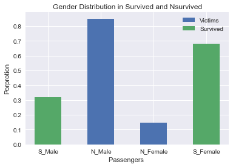

|  | Female | Male |
| --- | --- | --- |
| Nsurvivors | 81 | 467 |
| Survivors | 232 | 109 |

```python
fig,axes = plt.subplots()
axes.bar([2,3],[len(N_sex_m)/549.0,len(N_sex_w)/549.0],width = 0.5)
axes.bar([1,4],[len(sex_m)/340.0,len(sex_w)/340.0],width=0.5)
axes.legend(['Victims','Survived'])
axes.set_ylabel('Porprotion')
axes.set_xlabel('Passengers ')
axes.set_title('Gender Distribution in Survived and Nsurvived')
plt.setp(axes,xticks = [y+1for y in range(4)],xticklabels = ['S_Male','N_Male','N_Female','S_Female'])
plt.show()

df1 = pd.DataFrame({'Male':[len(N_sex_m),len(sex_m)],'Female':[len(N_sex_w),len(sex_w)]},index =['Nsurvivors','Survivors'])
display(df1)
```

> In this figure ,we can found the man's rate in Nsurvived are appeartly highter than Survived ,then I investage some documents,found the captain insisted on the women and children escaped at first when the accidents happened. So,I detected the age distribution based on different gender

## What's the age impact in different sex on survivals?

```python
S_age = Survivers.Age
Ns_age = Nsurvivers.Age
s_age = S_age[S_age<100]
ns_age = Ns_age[Ns_age<100]
num = len(S_age)-len(s_age)
print('The number of missed age values in survivers :%s'%num)
```

```
The number of missed age values in survivers :52
```

> Because there were many missed age value in both group ,I only use the existed age value to analyze

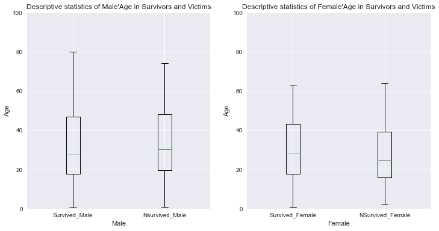

```python
grouped = Survivers.groupby(['Sex'])

s_age_m = Survivers[(Survivers.Age<100) &(Survivers.Sex=='male')]
s_age_w = grouped.get_group('female')
s_age_w = s_age_w[s_age_w.Age<100]

ngrouped = Nsurvivers[Nsurvivers.Age<100].groupby('Sex')
ns_age_w = ngrouped.get_group('female')
ns_age_m = ngrouped.get_group('male')

fig,ax = plt.subplots(ncols=2,nrows=1,figsize=(12,6))

ax[0].boxplot([s_age_m.Age.describe(),ns_age_m.Age.describe()])
ax[0].set_xticks([y+1 for y in [0,1]])
ax[0].set_ylim(0,100)
ax[0].set_xlabel('Male')
ax[0].set_ylabel('Age')
ax[0].set_title('Descriptive statistics of Male\'Age in Survivors and Victims')


ax[1].boxplot([s_age_w.Age.describe(),ns_age_w.Age.describe()])
ax[1].set_xticks([y+1 for y in [0,1]])
ax[1].set_ylim(0,100)
ax[1].set_xlabel('Female')
ax[1].set_ylabel('Age')
ax[1].set_title('Descriptive statistics of Female\'Age in Survivors and Victims')

plt.setp(ax[0],xticks =[y+1 for y in [0,1]],xticklabels=['Survived_Male','Nsurvived_Male'])
plt.setp(ax[1],xticks = [y+1 for y in [0,1]],xticklabels=['Survived_Female','NSurvived_Female'])

plt.show()
```

> Based on the graph ,the Age in different groups seem not much impact on whether one could surivated .To identity it ,I check the histogram of frequency distribution of survivors and victims in gender and age.

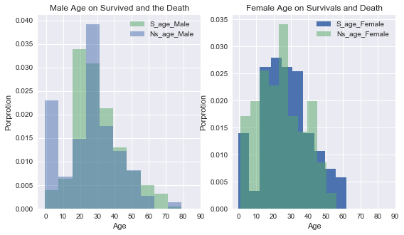

```python
grouped = Survivers.groupby(['Sex'])

s_age_m = Survivers[(Survivers.Age<100) &(Survivers.Sex=='male')]
s_sex_w = grouped.get_group('female')
s_age_w = s_sex_w[s_sex_w.Age<100]

ngrouped = Nsurvivers[Nsurvivers.Age<100].groupby('Sex')
ns_age_w = ngrouped.get_group('female')
ns_age_m = ngrouped.get_group('male')

fig,ax = plt.subplots(ncols=2,nrows=1,figsize=(9,5))

size=[0,10,20,30,40,50,60,70,80,90]
label = [str(i) for i in size]
#kwargs = histtype='stepfilled', alpha=0.3, normed=True, bins=10

ax[0].hist([s_age_m.Age,ns_age_m.Age],histtype='stepfilled', alpha=0.5, normed=True, bins=10)
ax[0].set_xticks([y+1 for y in size])
ax[0].set_xlabel('Age')
ax[0].set_title('Male Age on Survived and the Death')
ax[0].set_ylabel('Porprotion')
ax[0].legend(['S_age_Male','Ns_age_Male'])

# plot the victims's figure
ax[1].hist(s_age_w.Age,histtype='stepfilled',normed=True, bins=10)
ax[1].hist(ns_age_w.Age, histtype='stepfilled',alpha = 0.5,normed=True,bins=10)
ax[1].set_xticks([y+1 for y in size])
ax[1].set_xlabel('Age')
ax[1].set_ylabel('Porprotion')
ax[1].set_title('Female Age on Survivals and Death')
ax[1].legend(['S_age_Female','Ns_age_Female'])

plt.setp(ax[0], xticks=[y+1 for y in size], xticklabels=label)
plt.setp(ax[1], xticks=[y+1 for y in size], xticklabels=label)

plt.show()
```

```python
Age_compare = pd.DataFrame([s_age.describe(),ns_age.describe()],
                           index = ['Survived','Dead'])
display(Age_compare)
```

|  | count | mean | std | min | 25% | 50% | 75% | max |
| --- | --- | --- | --- | --- | --- | --- | --- | --- |
| Survived | 289.0 | 28.310277 | 14.966036 | 0.42 | 19.0 | 28.0 | 36.0 | 80.0 |
| Dead | 423.0 | 30.646572 | 14.182662 | 1.00 | 21.0 | 28.0 | 39.0 | 74.0 |

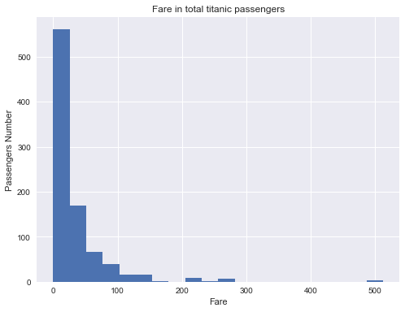

|  | PassengerId | Survived | Pclass | Name | Sex | Age | SibSp | Parch | Ticket | Fare | Cabin | Embarked |
| --- | --- | --- | --- | --- | --- | --- | --- | --- | --- | --- | --- | --- |
| 258 | 259 | 1 | 1 | Ward, Miss. Anna | female | 35.0 | 0 | 0 | PC 17755 | 512.3292 | None | C |
| 679 | 680 | 1 | 1 | Cardeza, Mr. Thomas Drake Martinez | male | 36.0 | 0 | 1 | PC 17755 | 512.3292 | B51 B53 B55 | C |
| 737 | 738 | 1 | 1 | Lesurer, Mr. Gustave J | male | 35.0 | 0 | 0 | PC 17755 | 512.3292 | B101 | C |

```python
fig,ax=plt.subplots(figsize=(8,6))
ax.hist(titanic_data.Fare,bins=20)
ax.set_xlabel('Fare')
ax.set_title('Fare in total titanic passengers')
ax.set_ylabel('Passengers Number')
plt.show()
display(titanic_data[titanic_data.Fare > 400])
```

> From the graph ,we could found there has some large outer, there were all survived .and they were all in the same Ticket.

```python
s_male = Survivers.groupby(['Sex']).get_group('male')
s_female = Survivers.groupby(['Sex']).get_group('female')
ns_male = Nsurvivers.groupby('Sex').get_group('male')
ns_female = Nsurvivers.groupby('Sex').get_group('female')
# each part porprozation
df1 = pd.DataFrame([s_male.Fare.describe(),
                    ns_male.Fare.describe(),
                    s_female.Fare.describe(),
                    ns_female.Fare.describe()],index=['s_male','ns_male','s_female','ns_female'])
display(df1)
```

|  | count | mean | std | min | 25% | 50% | 75% | max |
| --- | --- | --- | --- | --- | --- | --- | --- | --- |
| s_male | 109.0 | 40.821484 | 71.355967 | 0.000 | 9.5000 | 26.2875 | 39.000000 | 512.3292 |
| ns_male | 467.0 | 21.992494 | 32.437382 | 0.000 | 7.7979 | 9.4833 | 26.000000 | 263.0000 |
| s_female | 232.0 | 51.855191 | 64.228191 | 7.225 | 13.0000 | 26.0000 | 76.401075 | 512.3292 |
| ns_female | 81.0 | 23.024385 | 24.821287 | 6.750 | 8.8500 | 15.2458 | 27.900000 | 151.5500 |

```python
titanic_data[titanic_data.Fare>500]
```

|  | PassengerId | Survived | Pclass | Name | Sex | Age | SibSp | Parch | Ticket | Fare | Cabin | Embarked |
| --- | --- | --- | --- | --- | --- | --- | --- | --- | --- | --- | --- | --- |
| 258 | 259 | 1 | 1 | Ward, Miss. Anna | female | 35.0 | 0 | 0 | PC 17755 | 512.3292 | None | C |
| 679 | 680 | 1 | 1 | Cardeza, Mr. Thomas Drake Martinez | male | 36.0 | 0 | 1 | PC 17755 | 512.3292 | B51 B53 B55 | C |
| 737 | 738 | 1 | 1 | Lesurer, Mr. Gustave J | male | 35.0 | 0 | 0 | PC 17755 | 512.3292 | B101 | C |

> There were only three people have the Fare above 500,maybe there were the special people,however,it doesn't atttribute to our analysis,so we should not consider them in the Fare and reanalyse it.

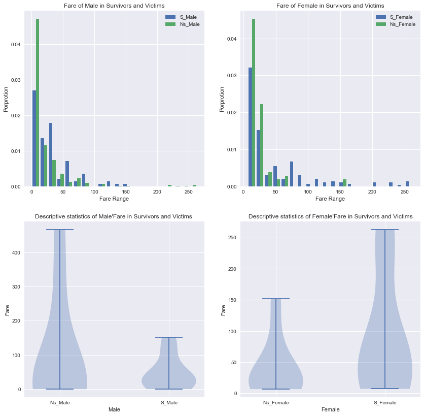

```python
s_male = s_male[s_male.Fare.apply(lambda x:x<500)]
s_female = s_female[s_female.Fare.apply(lambda x:x<500)]

figure,((ax1,ax2),(ax3,ax4)) = plt.subplots(figsize=(14,14),nrows =2,ncols=2)

X1 = [s_male.Fare,ns_male.Fare]
ax1.hist(X1,normed=True,bins=20)
ax1.set_ylabel('Porprotion')
ax1.set_xlabel('Fare Range')
ax1.legend(['S_Male','Ns_Male'])
ax1.set_title('Fare of Male in Survivors and Victims')

ax2.hist([s_female.Fare,ns_female.Fare],normed=True, bins=20)
ax2.set_ylabel('Porprotion')
ax2.set_xlabel('Fare Range')
ax2.legend(['S_Female','Ns_Female'])
ax2.set_title('Fare of Female in Survivors and Victims')

ax3.violinplot([ns_male.Fare.describe(),s_male.Fare.describe()])
ax3.set_xticks([y for y in [1,2]])
ax3.set_title('Descriptive statistics of Male\'Fare in Survivors and Victims ')
ax3.set_ylabel('Fare')
ax3.set_xlabel('Male')

ax4.violinplot([ns_female.Fare.describe(),s_female.Fare.describe()])
ax4.set_title('Descriptive statistics of Female\'Fare in Survivors and Victims')
ax4.set_xticks([y for y in [1,2]])
ax4.set_ylabel('Fare')
ax4.set_xlabel('Female')

plt.setp(ax3, xticks=[y for y in [1,2]], xticklabels=['Ns_Male','S_Male'])
plt.setp(ax4, xticks=[y for y in [1,2]], xticklabels=['Ns_Female','S_Female'])


plt.show()
```

## Conclusion

> There are still many problems not answer,such as Does the Pclass influence the survival? Does it revelant to the Fare ?  
> In the process of data investigation , as you diving in ,you 'll comefront many puzzles beyond your expectations.At first , we found the gender are different in survived and the dead . Considered the physical factor,then we study whether the age impact the survivals . according to the results , it seems doesn't much effect the survived. Given the missed values,we only can conclude that the age of survived male has a similar distribution with the deaded female,the survived female has a similar distributin with the deaded men. It also need to study whether they were might be a family ? It also need more reasearch. The Fare in survivals and victims were both in the majority, because there were more than 700 passengers have the fare under 100. Having high Fare passenger were rarely .Though browsing history ,I discovered the children and women were escaped firstly when the according happened.the age distribution doesn't has a positive distribution. During the Age study,the question about whether loss some survivors'age data still not clear.